# Analysis (simplified): bodyfat prediction

- Show All Code
- Hide All Code
- View Source

2024

Contrast-Bayes-Frequentist

STRATOS

R

Classification: confidential

Author

Affiliation

Georg Heinze

Medical University of Vienna, Center for Medical Data Science

Published

June 24, 2025

## 0.1 Preliminaries

This analysis report relates to SAPI V1.1 for the Analysis of bodyfat example (simplified).

## 0.2 Load libraries

```r
library(mfp2)

library(here)
library(dplyr)
library(tidyr)
library(ggplot2)
library(tidyselect)
library(gt)
library(gtExtras)
library(patchwork)
library(Hmisc)
library(sjlabelled)
```

# 1 Model estimation

## 1.1 Load data

```r
load("../Datafiles/bodyfatdata.Rdata")
```

## 1.2 Main data analysis

### 1.2.1 Description of observational units

```r
library(dplyr)
library(table1)


# Assume these are your two existing datasets
# data_women <- ...
# data_men <- ...

# Add Gender variable to each
data_women <- women %>% mutate(Gender = "1-Women")
data_men   <- men %>% mutate(Gender = "2-Men")

# Combine them into one dataset
data <- bind_rows(data_women, data_men)


my.render.cont <- function(x) {
        sprintf("%0.1f (%0.1f)\n[%0.1f – %0.1f]",
               mean(x, na.rm=TRUE), sd(x, na.rm=TRUE), min(x, na.rm=TRUE), max(x, na.rm=TRUE))
}

# Label variables
label(data$Fat) <- "Body Fat (%)"
label(data$Weight) <- "Weight (kg)"
label(data$Height) <- "Height (m)"
label(data$BMI) <- "BMI (kg/m^2)"
label(data$Age) <- "Age (years)"
label(data$Neck) <- "Neck (cm)"
label(data$Chest) <- "Chest (cm)"
label(data$Calf) <- "Calf (cm)"
label(data$Biceps) <- "Biceps (cm)"
label(data$Hips) <- "Hips (cm)"
label(data$Waist) <- "Waist (cm)"
label(data$Forearm) <- "Forearm (cm)"
label(data$PThigh) <- "Proximal Thigh (cm)"
label(data$MThigh) <- "Middle Thigh (cm)"
label(data$DThigh) <- "Distal Thigh (cm)"
label(data$Wrist) <- "Wrist (cm)"
label(data$Knee) <- "Knee (cm)"
label(data$Elbow) <- "Elbow (cm)"
label(data$Ankle) <- "Ankle (cm)"

# Generate Table 1


table1(~ Fat + Weight + Height + BMI + Age + Neck + Chest  + Biceps +
         Hips + Waist + Forearm +  MThigh  + Wrist + Knee +
          Ankle | Gender, data = data, render.continuous = my.render.cont, overall = NULL)
```

|  | 1-Women (N=184) | 2-Men (N=252) |
| --- | --- | --- |
| Body Fat (%) | 21.8 (5.8) [7.5 – 38.5] | 19.2 (8.4) [0.0 – 47.5] |
| Weight (kg) | 60.1 (8.2) [42.2 – 86.2] | 81.3 (13.4) [53.9 – 165.1] |
| Height (m) | 1.7 (0.1) [1.5 – 1.8] | 1.8 (0.1) [1.6 – 2.0] |
| BMI (kg/m^2) | 21.6 (2.7) [15.8 – 31.1] | 25.5 (3.7) [18.1 – 49.0] |
| Age (years) | 20.5 (1.6) [18.0 – 25.0] | 44.9 (12.6) [22.0 – 81.0] |
| Neck (cm) | 31.5 (1.5) [26.0 – 36.0] | 38.0 (2.4) [31.1 – 51.2] |
| Chest (cm) | 85.4 (5.0) [73.5 – 100.0] | 100.8 (8.4) [79.3 – 136.2] |
| Biceps (cm) | 26.6 (2.5) [20.5 – 34.5] | 32.3 (3.0) [24.8 – 45.0] |
| Hips (cm) | 96.9 (6.1) [82.5 – 115.0] | 99.9 (7.2) [85.0 – 147.7] |
| Waist (cm) | 69.5 (6.4) [58.0 – 96.0] | 92.6 (10.8) [69.4 – 148.1] |
| Forearm (cm) | 23.5 (1.6) [20.0 – 29.0] | 28.7 (2.0) [21.0 – 34.9] |
| Middle Thigh (cm) | 51.4 (4.1) [38.0 – 63.0] | 59.4 (5.2) [47.2 – 87.3] |
| Wrist (cm) | 15.6 (0.9) [13.5 – 19.0] | 18.2 (0.9) [15.8 – 21.4] |
| Knee (cm) | 35.7 (2.2) [31.0 – 42.0] | 38.6 (2.4) [33.0 – 49.1] |
| Ankle (cm) | 21.3 (1.3) [18.0 – 25.0] | 23.1 (1.7) [19.1 – 33.9] |

### 1.2.2 Objective 1: Model development and internal assessment

#### 1.2.2.1 Model estimation

Define a function that fits the model.

```r
# Function to derive the model with p predictors

# x = predictor matrix with column names being the labels



fit_rlasso <- function(x, y, p_final){
  n <- nrow(x)
  fit_glmnet <- glmnet(x=x, y=y, family="gaussian", relax=T)
  coef_mat <- coef(fit_glmnet$relaxed)
  num_nonzero <- apply(coef_mat, 2, function(v) sum(v != 0))-1
  target_lambda_index <- max(which(num_nonzero <= p_final))
  target_s <- min(fit_glmnet$lambda[num_nonzero <=p_final])
  active_coef <- coef_mat[, target_lambda_index]
  active_predictors <- rownames(coef_mat)[which(active_coef != 0)]
  fitted <- cbind(1,x) %*% active_coef
  residuals <- y - fitted
  residual_se <- sqrt(sum(residuals^2)/(n-1-p_final))
  return(list(coef=active_coef, residual_se=residual_se, residuals=residuals, fitted=fitted, relaxed=fit_glmnet$relaxed, fit=fit_glmnet, s=target_s))
}
```

Fit the model:

```r
library(glmnet)
predictors <- c("Weight", "Height", "BMI", "Age",
  "Neck", "Chest",  "Biceps", "Hips", "Waist",
  "Forearm",  "MThigh",  "Wrist",
  "Knee", "Ankle")
p <- length(predictors)

x <- as.matrix(women[, predictors])
y <- as.numeric(women$Fat)
n <- nrow(x)

# fit the coefficient path
fit_glmnet <- fit_rlasso(x=x, y=y, p_final=5)


ypred_orig <- predict(fit_glmnet$relaxed, newx=x, s=fit_glmnet$s)
```

#### 1.2.2.2 Model stability

Repeat the model building process 1000 times on bootstrap samples and store the coefficients and the predictions from the model on the original data:

```r
p_final <- 5
sel_orig <- fit_glmnet$coef !=0

B <- 1000

coef_b <- matrix(NA, nrow=B, ncol=ncol(x)+1)
colnames(coef_b) <- names(fit_glmnet$coef)

pred_b <- matrix(NA, nrow=B, ncol=nrow(x))

rsq_app <- rsq_test <- se_b <- model_sel <- (1:B)*0

set.seed(7123981)

for(b in 1:B){
  indb <- sample(1:nrow(x), repl=T)
  xb <- x[indb,]
  yb <- y[indb]

  fitb <- fit_rlasso(x=xb, y=yb, p_final=p_final)

  pred_b[b,] <- predict(fitb$relaxed, s=fitb$s, newx=x)
  coef_b[b,][names(fitb$coef)] <- fitb$coef
  model_sel <- prod((fitb$coef!=0) == sel_orig) # 1 if exactly equal to originally selected model, 0 else
  se_b[b] <- fitb$residual_se

  rsq_app[b] <- 1 - fitb$residual_se^2/var(yb)
  rsq_test[b] <- 1- var(predict(fitb$relaxed, s=fitb$s, newx=x) - y)/var(y)
}


sel_prob <- apply(coef_b, 2, function(X) mean(X!=0))   # selection probabilities for predictors
model_prob <- mean(model_sel)   # model selection probability
```

Evaluate stability results:

Instability plot of predictions

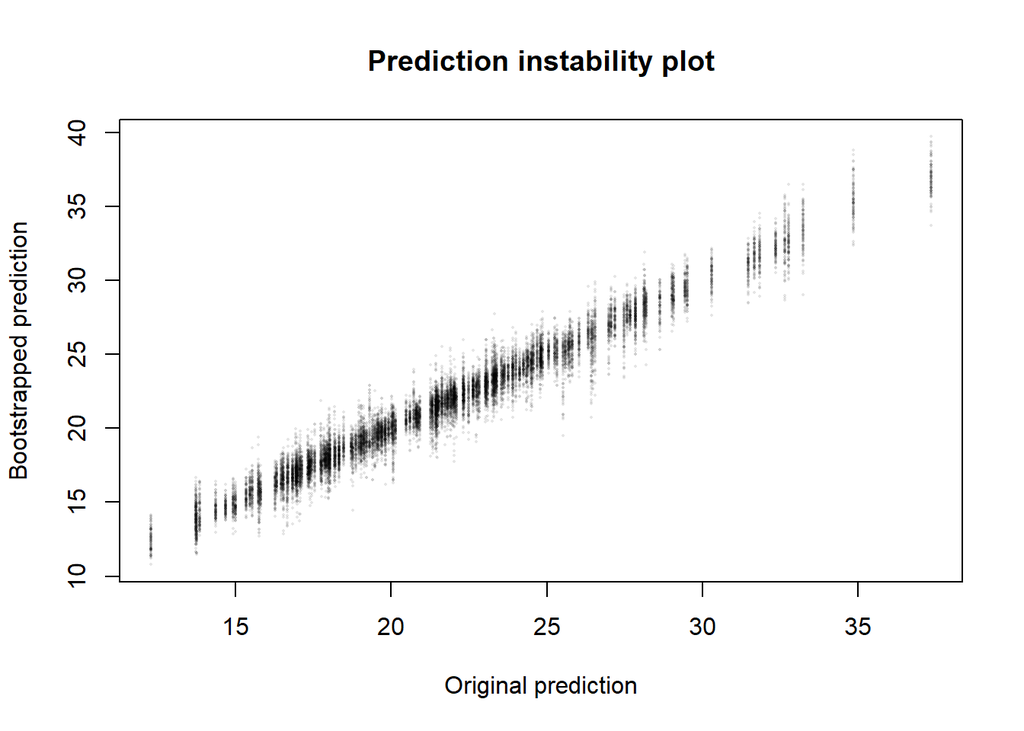

```r
matplot(fit_glmnet$fitted, t(pred_b[1:100,]),
        pch = 16,              # solid dots
        cex = 0.3,             # small point size
        col = rgb(0, 0, 0, 0.1), # semi-transparent black
        main = "Prediction instability plot",
        xlab = "Original prediction", ylab = "Bootstrapped prediction")
```

Bootstrap RMSE of prediction vs. model-based standard error of fitted values

```r
# bootstrap RMSE of prediction
rmse_pred <- apply(pred_b, 1, function(X) sqrt(mean((fit_glmnet$fitted - X)^2)))

cat("Bootstrap RMSE of fitted values (selected):", mean(rmse_pred), "\n")
```

```
Bootstrap RMSE of fitted values (selected): 0.8231749
```

```r
# model-based RMSE of prediction
xmod <- cbind(1,x[,fit_glmnet$coef[-1]!=0])
invXtX <-solve(t(xmod) %*% xmod)

mse_mod <- sapply(1:nrow(x), function(X) fit_glmnet$residual_se^2*t(xmod[X,]) %*% invXtX %*% xmod[X,])
cat("(Model-based RMSE of fitted values:", sqrt(mean(mse_mod)), ")\n")
```

```
(Model-based RMSE of fitted values: 0.6399374 )
```

```r
# Pairwise selection probabilities

sel_b <- (coef_b!=0)[,-1]
ncoef <- ncol(sel_b)

exp_pw_sel <- pw_sel <- zscore <- matrix(0,nrow=ncoef, ncol=ncoef)
rownames(pw_sel) <- colnames(pw_sel) <- rownames(zscore) <- colnames(zscore) <- predictors

diag(pw_sel) <- sel_prob[-1]



for(j in 1:(ncoef-1)){
  for(jj in (j+1):ncoef){
    exp_pw_sel[j,jj] <- sel_prob[j+1]*sel_prob[jj+1]
    pw_sel[jj,j] <- pw_sel[j,jj] <- mean(sel_b[,j]*sel_b[,jj])
    zscore[jj,j] <- zscore[j,jj] <- sign(pw_sel[j,jj]-exp_pw_sel[j,jj])*sqrt((pw_sel[j,jj]-exp_pw_sel[j,jj])^2/exp_pw_sel[j,jj]*B)
  }
}
```

#### 1.2.2.3 Model description

```r
library(knitr)
# assemble data

results_beta <- matrix(0, nrow=length(fit_glmnet$coef), ncol=5)
rownames(results_beta) <- names(fit_glmnet$coef)
colnames(results_beta) <- c("Regression coefficient", "Standardized beta", "Variable inclusion frequency", "Lower 95% confidence limit", "Upper 95% confidence limit")

results_beta[,1] <- fit_glmnet$coef
results_beta[,2] <- fit_glmnet$coef*c(1,apply(x, 2, sd))
results_beta[,3] <- sel_prob
results_beta[,4] <- apply(coef_b,2,quantile, 0.025)
results_beta[,5] <- apply(coef_b,2,quantile, 0.975)

results_beta<-results_beta[order(-abs(results_beta[,3])),]
kable(results_beta, format="html", caption="Regression coefficients and stability measures")
```

Regression coefficients and stability measures

|  | Regression coefficient | Standardized beta | Variable inclusion frequency | Lower 95% confidence limit | Upper 95% confidence limit |
| --- | --- | --- | --- | --- | --- |
| (Intercept) | -35.8567775 | -35.8567775 | 1.000 | -46.0949017 | -0.8635916 |
| Waist | 0.2074769 | 1.3338429 | 0.978 | 0.0524680 | 0.4220547 |
| BMI | 0.7215750 | 1.9475939 | 0.977 | -0.2001433 | 1.2139484 |
| Hips | 0.1632254 | 0.9994807 | 0.958 | 0.0000000 | 0.4697224 |
| Knee | 0.2594271 | 0.5612850 | 0.806 | 0.0000000 | 0.7050692 |
| Biceps | 0.0942895 | 0.2318775 | 0.570 | 0.0000000 | 0.4737582 |
| Height | 0.0000000 | 0.0000000 | 0.277 | -28.0185071 | 0.0000000 |
| Ankle | 0.0000000 | 0.0000000 | 0.084 | -1.0689316 | 0.0000000 |
| MThigh | 0.0000000 | 0.0000000 | 0.080 | 0.0000000 | 0.1375382 |
| Wrist | 0.0000000 | 0.0000000 | 0.068 | -1.6003007 | 0.0000000 |
| Age | 0.0000000 | 0.0000000 | 0.056 | 0.0000000 | 0.2471138 |
| Neck | 0.0000000 | 0.0000000 | 0.018 | 0.0000000 | 0.0000000 |
| Chest | 0.0000000 | 0.0000000 | 0.011 | 0.0000000 | 0.0000000 |
| Weight | 0.0000000 | 0.0000000 | 0.004 | 0.0000000 | 0.0000000 |
| Forearm | 0.0000000 | 0.0000000 | 0.001 | 0.0000000 | 0.0000000 |

Global model descriptors:

```r
# Apparent adjusted R-squared:
Rsq_adj <- (1 - (fit_glmnet$residual_se^2)/var(y))
Rsq_corr <- Rsq_adj - (mean(rsq_app)-mean(rsq_test))

global_desc <- c(residual_error = fit_glmnet$residual_se, boot_rmse=mean(rmse_pred), mod_rmse=sqrt(mean(mse_mod)), Rsq_adj=Rsq_adj, Rsq_corr=Rsq_corr)
names(global_desc) <- c("Residual error", "Bootstrap RMSE of fitted", "(Model-based RMSE of fitted)", "R-squared adj.", "Corrected R-squared")

kable(global_desc, caption="Global model descriptors")
```

Global model descriptors

|  | x |
| --- | --- |
| Residual error | 3.5438128 |
| Bootstrap RMSE of fitted | 0.8231749 |
| (Model-based RMSE of fitted) | 0.6399374 |
| R-squared adj. | 0.6282604 |
| Corrected R-squared | 0.6139631 |

Pairwise selection probabilities:

```r
kable(pw_sel*100, caption="Pairwise selection probabilities x 100", digits=0)
```

Pairwise selection probabilities x 100

|  | Weight | Height | BMI | Age | Neck | Chest | Biceps | Hips | Waist | Forearm | MThigh | Wrist | Knee | Ankle |
| --- | --- | --- | --- | --- | --- | --- | --- | --- | --- | --- | --- | --- | --- | --- |
| Weight | 0 | 0 | 0 | 0 | 0 | 0 | 0 | 0 | 0 | 0 | 0 | 0 | 0 | 0 |
| Height | 0 | 28 | 26 | 1 | 0 | 0 | 9 | 26 | 27 | 0 | 1 | 1 | 18 | 1 |
| BMI | 0 | 26 | 98 | 6 | 2 | 1 | 55 | 94 | 96 | 0 | 8 | 7 | 78 | 8 |
| Age | 0 | 1 | 6 | 6 | 0 | 0 | 1 | 5 | 5 | 0 | 0 | 0 | 3 | 0 |
| Neck | 0 | 0 | 2 | 0 | 2 | 0 | 0 | 2 | 2 | 0 | 0 | 0 | 1 | 0 |
| Chest | 0 | 0 | 1 | 0 | 0 | 1 | 0 | 1 | 1 | 0 | 0 | 0 | 1 | 0 |
| Biceps | 0 | 9 | 55 | 1 | 0 | 0 | 57 | 55 | 55 | 0 | 2 | 1 | 44 | 2 |
| Hips | 0 | 26 | 94 | 5 | 2 | 1 | 55 | 96 | 94 | 0 | 7 | 6 | 77 | 7 |
| Waist | 0 | 27 | 96 | 5 | 2 | 1 | 55 | 94 | 98 | 0 | 8 | 6 | 79 | 8 |
| Forearm | 0 | 0 | 0 | 0 | 0 | 0 | 0 | 0 | 0 | 0 | 0 | 0 | 0 | 0 |
| MThigh | 0 | 1 | 8 | 0 | 0 | 0 | 2 | 7 | 8 | 0 | 8 | 0 | 5 | 0 |
| Wrist | 0 | 1 | 7 | 0 | 0 | 0 | 1 | 6 | 6 | 0 | 0 | 7 | 5 | 0 |
| Knee | 0 | 18 | 78 | 3 | 1 | 1 | 44 | 77 | 79 | 0 | 5 | 5 | 81 | 6 |
| Ankle | 0 | 1 | 8 | 0 | 0 | 0 | 2 | 7 | 8 | 0 | 0 | 0 | 6 | 8 |

The following table of z-scores indicates if some pairs of variables were selected overly together (z-score is positive), or alternatively to each other (z-score negative):

```r
kable(zscore, caption="Z-scores for nonrandom pairwise selection", digits=1)
```

Z-scores for nonrandom pairwise selection

|  | Weight | Height | BMI | Age | Neck | Chest | Biceps | Hips | Waist | Forearm | MThigh | Wrist | Knee | Ankle |
| --- | --- | --- | --- | --- | --- | --- | --- | --- | --- | --- | --- | --- | --- | --- |
| Weight | 0.0 | -1.1 | 0.0 | -0.5 | -0.3 | -0.2 | -1.5 | -0.4 | 0.0 | -0.1 | 1.2 | -0.5 | -0.1 | 1.1 |
| Height | -1.1 | 0.0 | -1.0 | -2.4 | -1.3 | -1.2 | -5.2 | -0.5 | -0.3 | 1.4 | -1.7 | -1.3 | -3.0 | -2.8 |
| BMI | 0.0 | -1.0 | 0.0 | 0.2 | 0.1 | 0.1 | -0.3 | 0.0 | 0.0 | -1.0 | 0.0 | -0.1 | -0.1 | 0.2 |
| Age | -0.5 | -2.4 | 0.2 | 0.0 | 2.0 | 0.5 | -3.5 | -0.2 | -0.1 | -0.2 | -1.2 | -0.9 | -1.7 | -1.2 |
| Neck | -0.3 | -1.3 | 0.1 | 2.0 | 0.0 | -0.4 | -2.0 | -0.1 | -0.4 | -0.1 | -0.4 | 0.7 | -1.7 | -0.4 |
| Chest | -0.2 | -1.2 | 0.1 | 0.5 | -0.4 | 0.0 | -2.5 | -0.5 | -0.2 | -0.1 | 0.1 | 0.3 | -0.3 | 0.1 |
| Biceps | -1.5 | -5.2 | -0.3 | -3.5 | -2.0 | -2.5 | 0.0 | 0.1 | -0.2 | -0.8 | -4.1 | -4.5 | -0.9 | -4.5 |
| Hips | -0.4 | -0.5 | 0.0 | -0.2 | -0.1 | -0.5 | 0.1 | 0.0 | 0.0 | 0.0 | -0.6 | -0.6 | -0.2 | -0.7 |
| Waist | 0.0 | -0.3 | 0.0 | -0.1 | -0.4 | -0.2 | -0.2 | 0.0 | 0.0 | 0.0 | 0.1 | -0.2 | -0.1 | -0.3 |
| Forearm | -0.1 | 1.4 | -1.0 | -0.2 | -0.1 | -0.1 | -0.8 | 0.0 | 0.0 | 0.0 | -0.3 | 3.6 | -0.9 | -0.3 |
| MThigh | 1.2 | -1.7 | 0.0 | -1.2 | -0.4 | 0.1 | -4.1 | -0.6 | 0.1 | -0.3 | 0.0 | -1.9 | -2.2 | -1.0 |
| Wrist | -0.5 | -1.3 | -0.1 | -0.9 | 0.7 | 0.3 | -4.5 | -0.6 | -0.2 | 3.6 | -1.9 | 0.0 | -1.2 | -1.1 |
| Knee | -0.1 | -3.0 | -0.1 | -1.7 | -1.7 | -0.3 | -0.9 | -0.2 | -0.1 | -0.9 | -2.2 | -1.2 | 0.0 | -1.1 |
| Ankle | 1.1 | -2.8 | 0.2 | -1.2 | -0.4 | 0.1 | -4.5 | -0.7 | -0.3 | -0.3 | -1.0 | -1.1 | -1.1 | 0.0 |

#### 1.2.2.4 Assumptions and diagnostics: residual analysis

```r
# first, find the extended set of active predictors (8 predictors)

fit_ext <- fit_rlasso(x=x, y=y, p_final=8)
active_predictors <- names(fit_glmnet$coef)[fit_glmnet$coef!=0][-1]
active_predictors_ext <- names(fit_ext$coef)[fit_ext$coef!=0][-1]
```

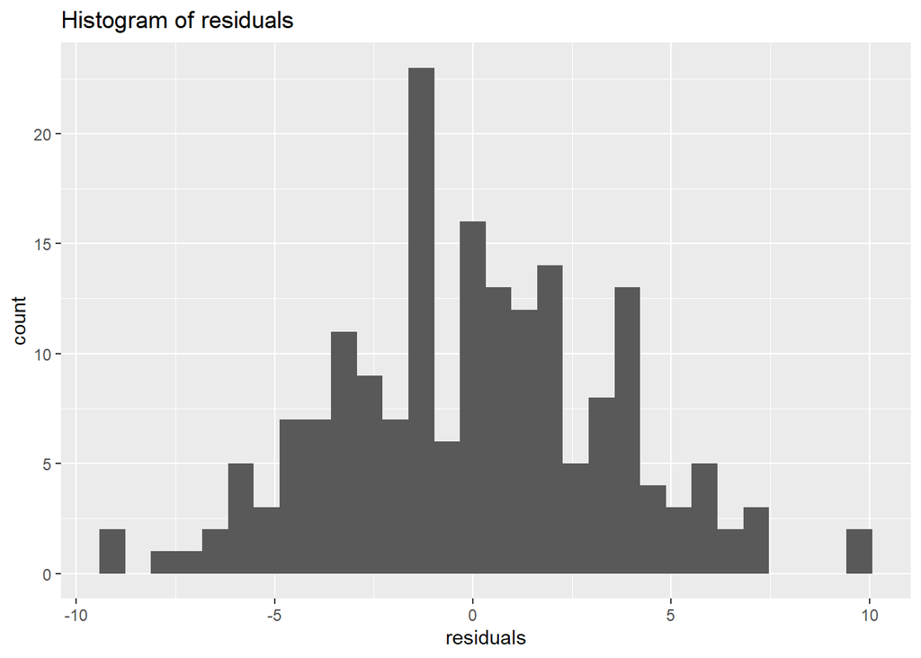

```r
library(ggplot2)

predictions <- fit_glmnet$fitted

residuals <- fit_glmnet$residuals

ggplot(data=data.frame(residuals), aes(x=residuals)) + geom_histogram() + ggtitle(label="Histogram of residuals")
```

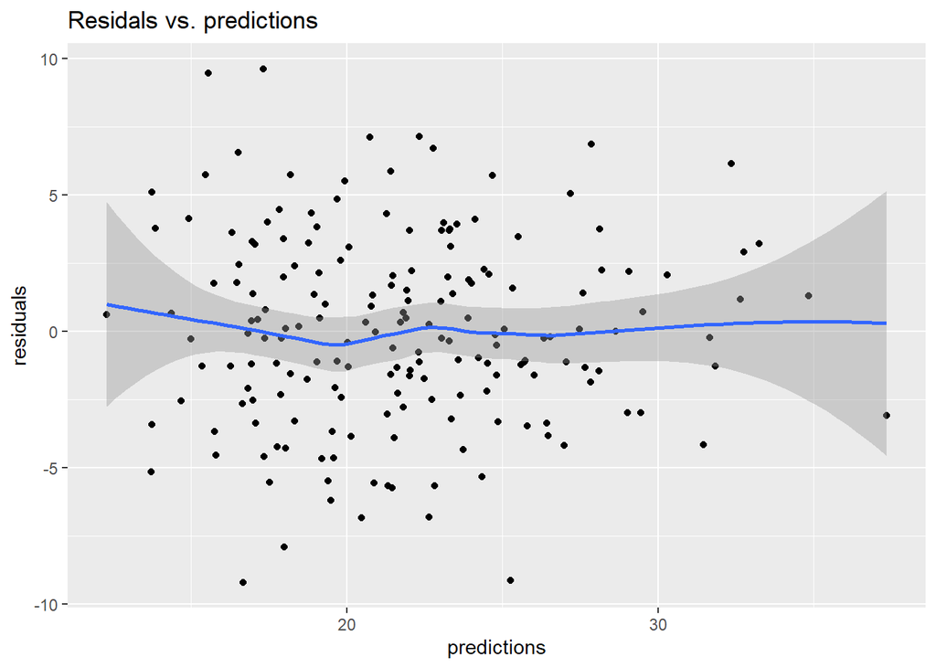

```r
sqrt_abs_res <- sqrt(abs(residuals))

ggplot(data=data.frame(residuals, predictions, y), aes(x=predictions, y=residuals)) + geom_point() + geom_smooth() + ggtitle(label="Residals vs. predictions")
```

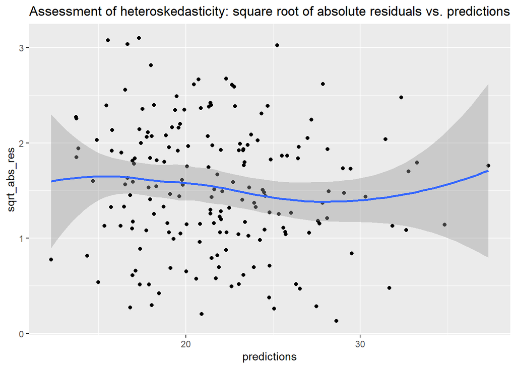

```r
ggplot(data=data.frame(sqrt_abs_res, predictions, y), aes(x=predictions, y=sqrt_abs_res)) + geom_point() + geom_smooth() + ggtitle(label="Assessment of heteroskedasticity: square root of absolute residuals vs. predictions")
```

In the following residual plots, the nearly-selected predictors are denoted by red dots, the selected predictors by blue dots.

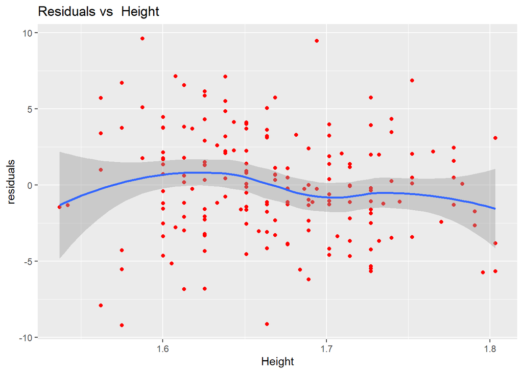

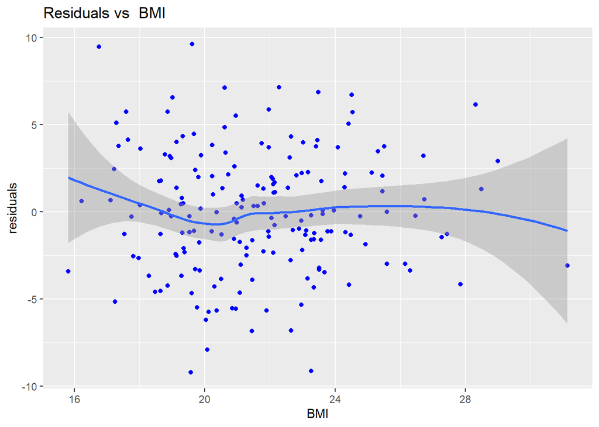

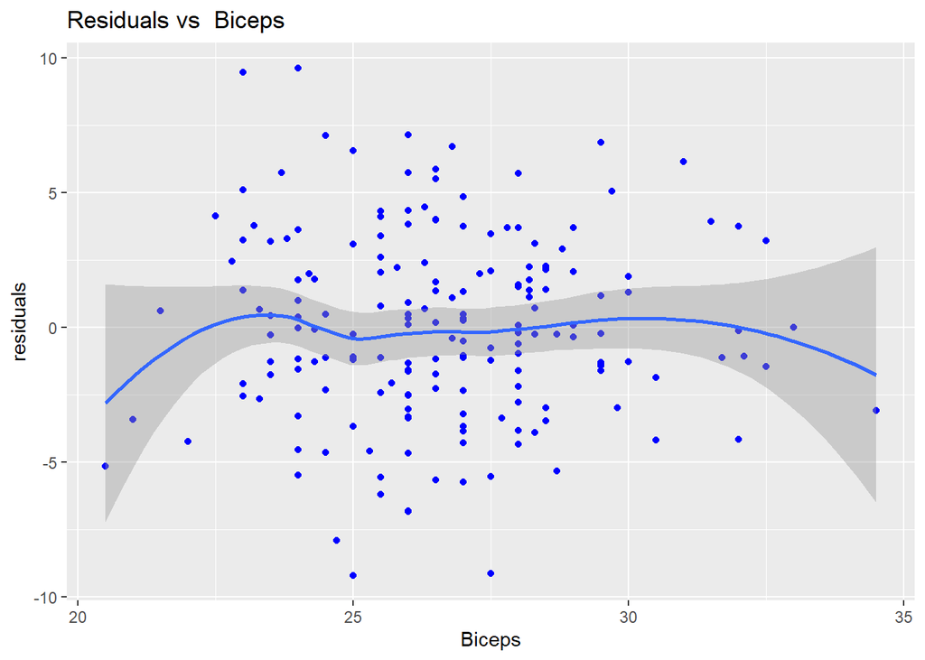

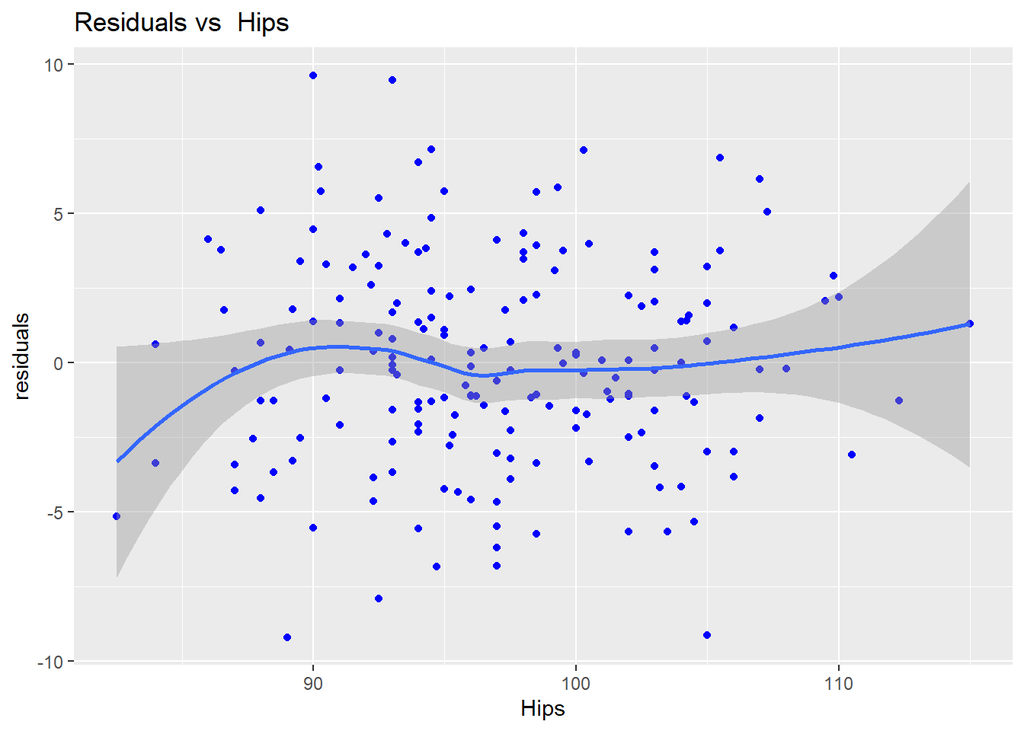

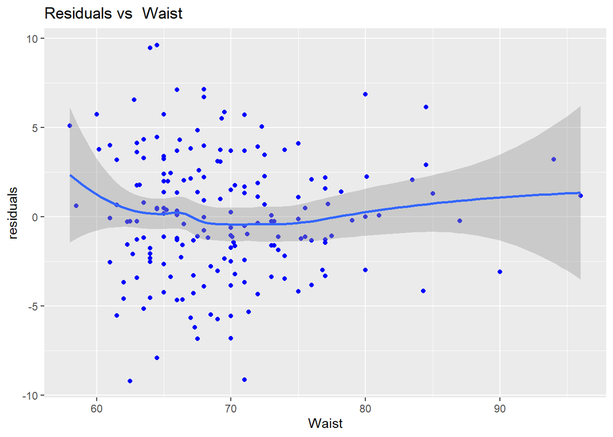

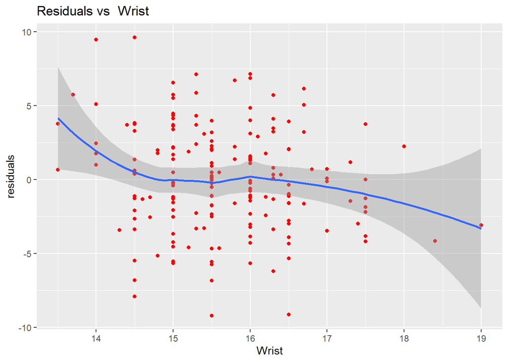

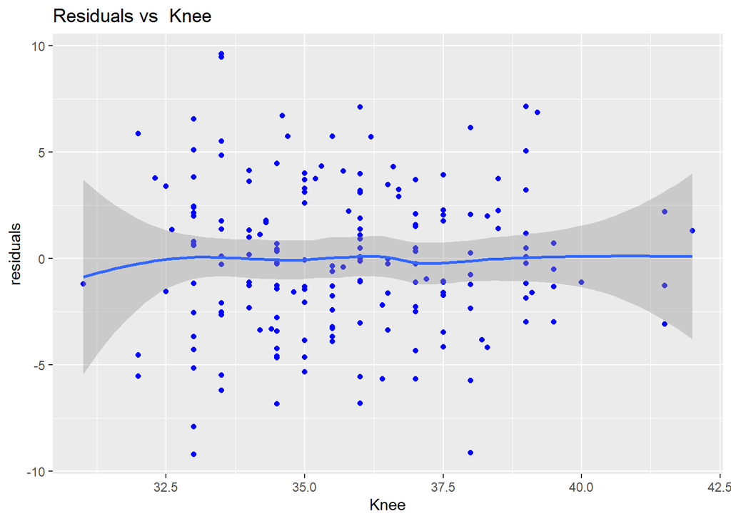

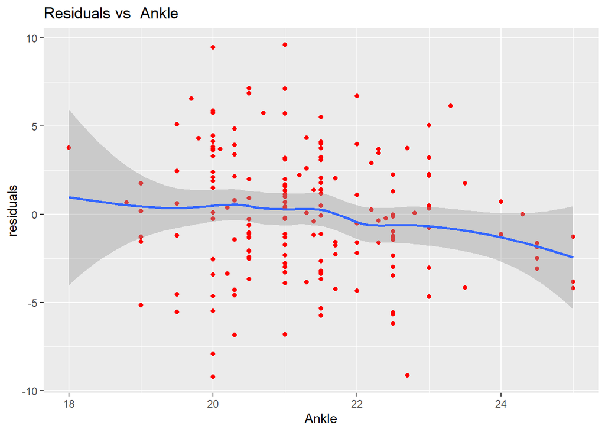

```r
for(v in active_predictors_ext){
  cols=ifelse(v %in% active_predictors, "blue", "red")
  print(ggplot(data=data.frame(residuals, variable=x[,v]), aes(x=variable, y=residuals), xlab(v)) + geom_point(color=cols) + geom_smooth() + xlab(v) + ggtitle(label=paste("Residuals vs ",v, collapse="")))

}
```

### 1.2.3 Objective 2: Model validation

```r
# Computing predictions in the men's data set

xmen <- as.matrix(men[, predictors])
ymen <- as.numeric(men$Fat)
ymean_men <- mean(ymen)
nmen <- nrow(xmen)

ypred_men <- predict(fit_glmnet$relaxed, s=fit_glmnet$s, newx=xmen)
res_men <- ymen - ypred_men

r2_val <- 1 - sum((ymen - ypred_men)^2)/sum((ymen - ymean_men)^2)
   #negative r2 because of miscalibration

#se_r2_val <- sqrt((4*r2_val*(1-r2_val)^2)/nmen)
#se_r2_val


rmspe <- sqrt(mean(res_men^2))

glob_pm <- c(r2_val, rmspe)
names(glob_pm) <- c("Validation R-squared", "Root mean squared prediction error")

kable(glob_pm, caption="Overall performance measures")
```

Overall performance measures

|  | x |
| --- | --- |
| Validation R-squared | -1.468229 |
| Root mean squared prediction error | 13.141202 |

Calibration plot:

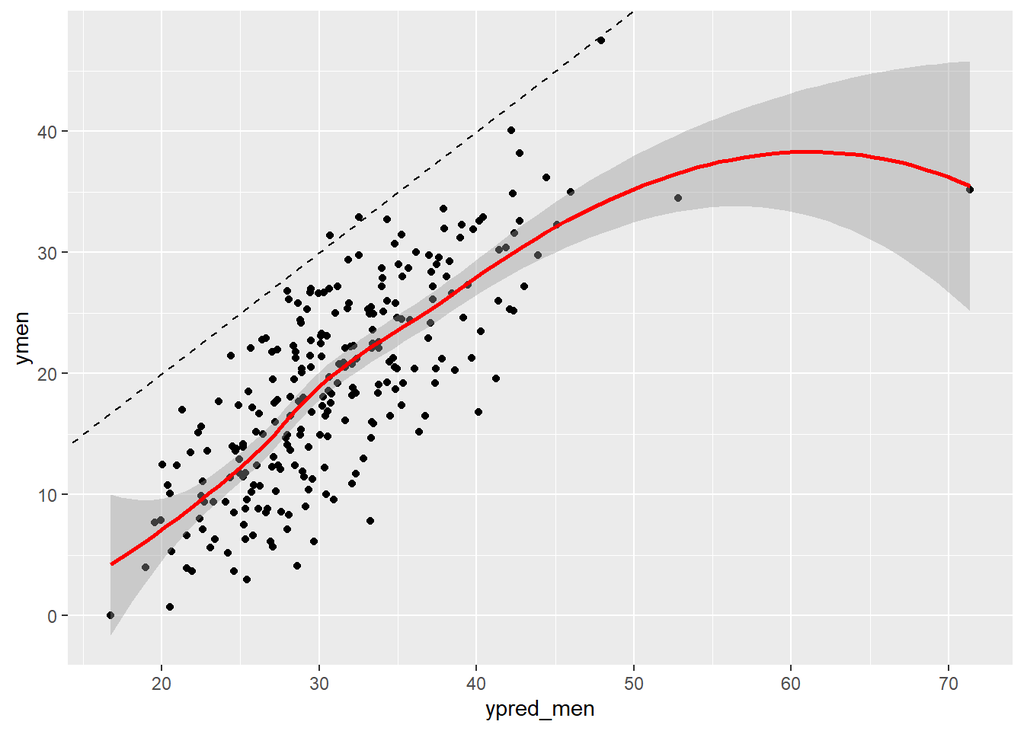

```r
# Calibration plot

ggplot(data.frame(ypred_men, ymen), aes(x=ypred_men, y=ymen)) + geom_point() + geom_smooth(col="red") + geom_abline(intercept=0, slope=1, linetype="dashed")
```

Calibration model:

```r
fit_cal <- lm(ymen ~ ypred_men)
summary(fit_cal)
```

```
Call:
lm(formula = ymen ~ ypred_men)

Residuals:
     Min       1Q   Median       3Q      Max
-22.5264  -3.8093   0.3755   4.1909  12.6172

Coefficients:
             Estimate Std. Error t value Pr(>|t|)
(Intercept) -10.62449    1.69042  -6.285 1.45e-09 ***
ypred_men     0.95822    0.05322  18.005  < 2e-16 ***
---
Signif. codes:  0 '***' 0.001 '**' 0.01 '*' 0.05 '.' 0.1 ' ' 1

Residual standard error: 5.541 on 250 degrees of freedom
Multiple R-squared:  0.5646,    Adjusted R-squared:  0.5629
F-statistic: 324.2 on 1 and 250 DF,  p-value: < 2.2e-16
```

```r
cal_slope <- coef(fit_cal)[2]

fit_cal0 <- lm(ymen ~ offset(ypred_men))
cal_int <- coef(fit_cal0)[1]


cal_stats <- c(cal_int, confint(fit_cal0), cal_slope, confint(fit_cal)[2,])

names(cal_stats) <- c("Calibration intercept", "Calibration intercept, lower 95% CL", "Calibration intercept, upper 95% CL", "Calibration slope", "Calibration slope, lower 95% CL", "Calibration slope, upper 95% CL")

kable(cal_stats, caption="Calibration statistics")
```

Calibration statistics

|  | x |
| --- | --- |
| Calibration intercept | -11.9228028 |
| Calibration intercept, lower 95% CL | -12.6097611 |
| Calibration intercept, upper 95% CL | -11.2358445 |
| Calibration slope | 0.9582249 |
| Calibration slope, lower 95% CL | 0.8534096 |
| Calibration slope, upper 95% CL | 1.0630403 |

It is easily seen that the calibration slope is very close to 1, but the intercept points towards a systematic overestimation of Fat in men by 11.9228 percentage point. As a remedy, one could propose a recalibrated model for men where the intercept is corrected by -11.9228028. This recalibrated model would achieve an apparent $R^2$ of 0.5635292.